# Exercise 2: CO2 modeling

2021-04-23

```r
library(tidyverse)
library(lubridate)
library(broom)
```

## Let’s fit a model to CO2

The Scripps CO2 program records atmospheric carbon dioxide measurements from sampled since 1957 at various stations around the world along the same longitude (why?) This link https://scrippsco2.ucsd.edu/data/atmospheric_co2/sampling_stations.html shows the different stations and provides links to the data.

We have extracted and downloaded data for the South Pole. If you have a look at this csv file, at what line does the data start?

```r
co2_spo <- read_csv("data/daily_merge_co2_spo.csv",
                    col_names = c("date",
                                  "time",
                                  "day",
                                  "decdate",
                                  "n",
                                  "flg",
                                  "co2"),
                    skip = 69) %>%
  mutate(lat = -90.0,
         lon = 0,
         stn = "spo") %>%
  filter(flg == 0) %>% # the flag recognises whether the value is accepted
  mutate(date = ymd(date)) %>%
#   First we re-scale to start from 1 until the number of days in the time frame.
  mutate(day0 = day - min(day))
co2_spo
```

```
## # A tibble: 1,202 x 11
##    date       time      day decdate     n   flg   co2   lat   lon stn    day0
##    <date>     <time>  <dbl>   <dbl> <dbl> <dbl> <dbl> <dbl> <dbl> <chr> <dbl>
##  1 1957-06-17 00:00  20988    1957.     1     0  313.   -90     0 spo      0
##  2 1957-12-22 00:00  21176    1958.     1     0  314.   -90     0 spo    188
##  3 1957-12-23 00:00  21177    1958.     1     0  314.   -90     0 spo    189
##  4 1958-03-21 00:00  21265    1958.     1     0  314.   -90     0 spo    277
##  5 1958-03-22 06:30  21266.   1958.     2     0  314.   -90     0 spo    278.
##  6 1958-06-20 00:00  21356    1958.     1     0  315.   -90     0 spo    368
##  7 1958-09-27 00:00  21455    1959.     1     0  315.   -90     0 spo    467
##  8 1958-09-28 00:00  21456    1959.     1     0  315.   -90     0 spo    468
##  9 1959-01-08 00:00  21558    1959.     1     0  315.   -90     0 spo    570
## 10 1959-01-12 00:00  21562    1959.     1     0  315.   -90     0 spo    574
## # … with 1,192 more rows
```

### Q1. Plot date against co2 with points

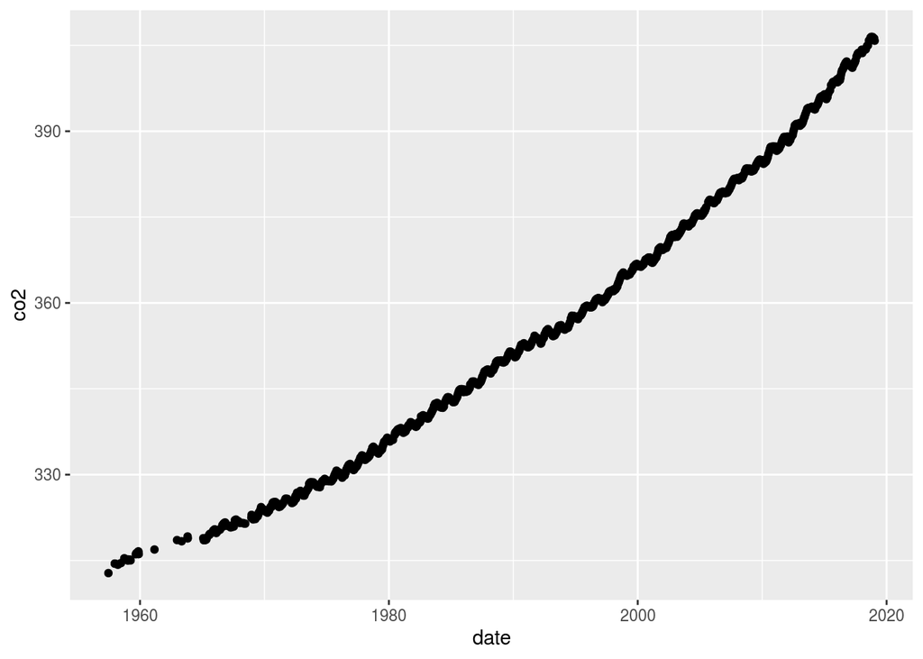

```r
ggplot(co2_spo,
       aes(x = date, y = co2)) +
  geom_point()
```

### Q2. Fit a linear model, using `day` variable as the explanatory variable and tidy it up

```r
co2_day_fit <- lm(co2 ~ day, data = co2_spo)
tidy(co2_day_fit)
```

```
## # A tibble: 2 x 5
##   term         estimate std.error statistic p.value
##   <chr>           <dbl>     <dbl>     <dbl>   <dbl>
## 1 (Intercept) 212.      0.543          391.       0
## 2 day           0.00428 0.0000159      269.       0
```

### Q3. Calculate the summary of day0 and day to compare `day` against `day0`

```r
summary(co2_spo$day)
```

```
##    Min. 1st Qu.  Median    Mean 3rd Qu.    Max.
##   20988   28875   33733   33609   38500   43480
```

```r
summary(co2_spo$day0)
```

```
##    Min. 1st Qu.  Median    Mean 3rd Qu.    Max.
##       0    7887   12745   12621   17512   22492
```

### Q4. “What is range of dates of this data?”

- The variables, day and day0 range from 1957-06-17 to 2019-01-15

### Q5. Fit a linear model, predicting co2 using day0

```r
co2_fit <- lm(co2 ~ day0, data = co2_spo)
co2_fit
```

```
##
## Call:
## lm(formula = co2 ~ day0, data = co2_spo)
##
## Coefficients:
## (Intercept)         day0
##   3.021e+02    4.285e-03
```

### Q6: Now we tidy up the output and store information on the intercept and slope so we can describe the fit

```r
library(broom)
tidy_co2_fit <- tidy(co2_fit)
tidy_co2_fit
```

```
## # A tibble: 2 x 5
##   term         estimate std.error statistic p.value
##   <chr>           <dbl>     <dbl>     <dbl>   <dbl>
## 1 (Intercept) 302.      0.221         1367.       0
## 2 day0          0.00428 0.0000159      269.       0
```

```r
int <- round(tidy_co2_fit$estimate[1], 4)
slope <- round(tidy_co2_fit$estimate[2], 4)
```

Then the fitted model will be:
$$\widehat{\text{co2}} = 302.0734 + 0.0043~\text{day0}$$

### Q7. What date is day0=10000? (Hint: use filter and select on the data to work it out)"

```r
co2_spo %>%
filter(as.integer(day0)==10000) %>%
select(date)
```

```
## # A tibble: 1 x 1
##   date
##   <date>
## 1 1984-11-02
```

### Q8. Plot the model

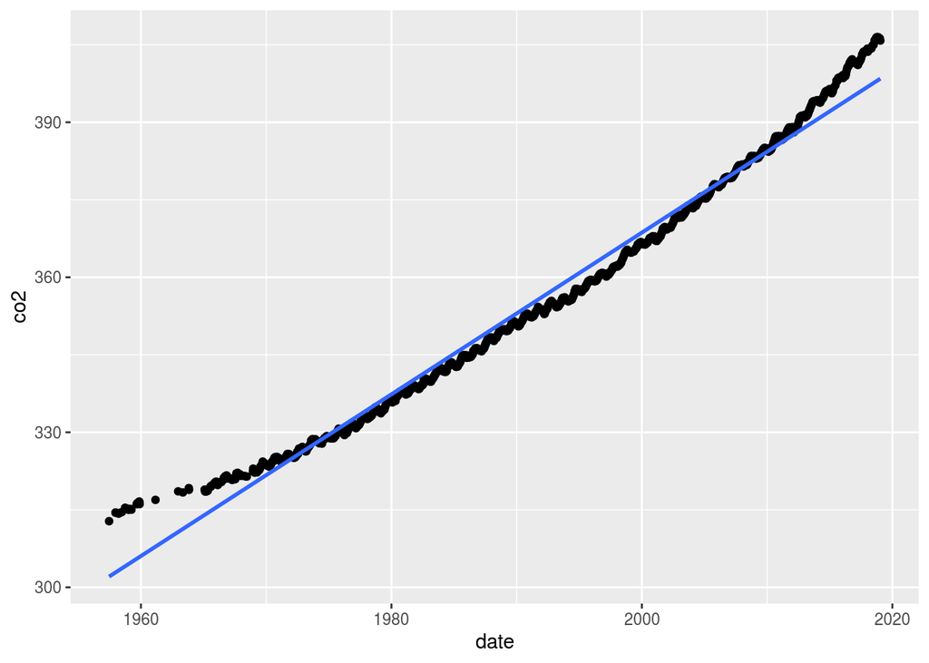

```r
ggplot(co2_spo,
       aes(x = date, y = co2)) +
  geom_point() +
  geom_smooth(method = "lm", se = FALSE)
```

### Q9. Use the `augment` function to extract residuals and fitted values, and pointwise diagnostics

```r
co2_model <- augment(co2_fit, co2_spo)

co2_model
```

```
## # A tibble: 1,202 x 17
##    date       time      day decdate     n   flg   co2   lat   lon stn    day0
##    <date>     <time>  <dbl>   <dbl> <dbl> <dbl> <dbl> <dbl> <dbl> <chr> <dbl>
##  1 1957-06-17 00:00  20988    1957.     1     0  313.   -90     0 spo      0
##  2 1957-12-22 00:00  21176    1958.     1     0  314.   -90     0 spo    188
##  3 1957-12-23 00:00  21177    1958.     1     0  314.   -90     0 spo    189
##  4 1958-03-21 00:00  21265    1958.     1     0  314.   -90     0 spo    277
##  5 1958-03-22 06:30  21266.   1958.     2     0  314.   -90     0 spo    278.
##  6 1958-06-20 00:00  21356    1958.     1     0  315.   -90     0 spo    368
##  7 1958-09-27 00:00  21455    1959.     1     0  315.   -90     0 spo    467
##  8 1958-09-28 00:00  21456    1959.     1     0  315.   -90     0 spo    468
##  9 1959-01-08 00:00  21558    1959.     1     0  315.   -90     0 spo    570
## 10 1959-01-12 00:00  21562    1959.     1     0  315.   -90     0 spo    574
## # … with 1,192 more rows, and 6 more variables: .fitted <dbl>, .resid <dbl>,
## #   .hat <dbl>, .sigma <dbl>, .cooksd <dbl>, .std.resid <dbl>
```

### Q10. Plot the date and co2 with points and add in the line

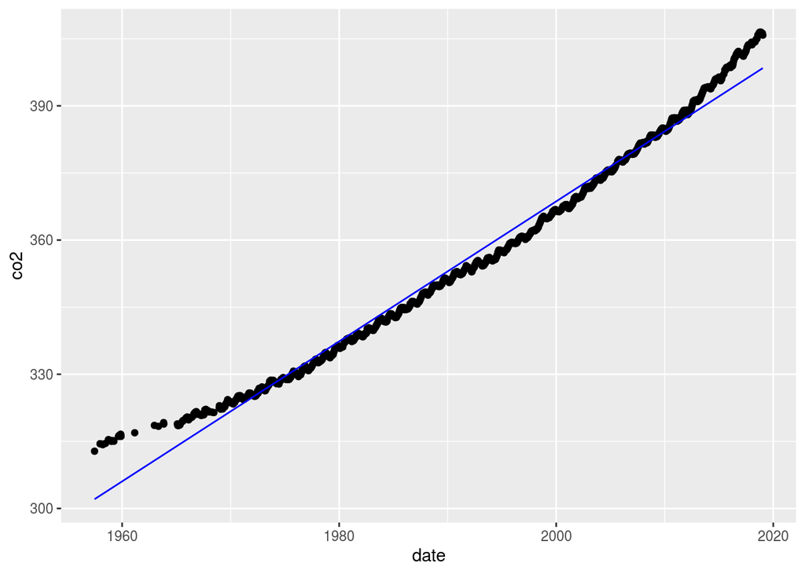

```r
ggplot(co2_model,
       aes(x = date,
           y = co2)) +
  geom_point() +
  geom_line(aes(y = .fitted), colour = "blue")
```

## Examine residuals

- **Residuals** are calculated for each observed $y$ by computing the difference: $y_i-\widehat{y_i}$.

### Q11. Plot residuals against fitted values to reveal problems with the fit.

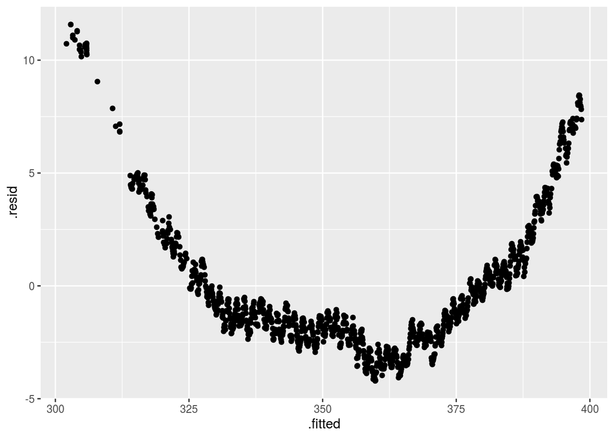

```r
ggplot(co2_model,
       aes(x = .fitted, y = .resid)) +
  geom_point()
```

### Q12. Investigate residuals using `resid_panel`.

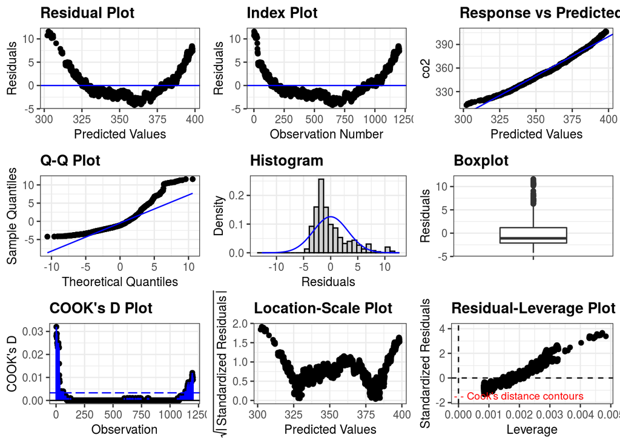

```r
library(ggResidpanel)
resid_panel(co2_fit, plots = "all")
```

## Assessment of fit

- The relationship between co2 and day0 is nonlinear!
- The linear model does a reasonable job of explaining the increasing trend over time, but it especially mismatches the observed data at the ends, and middle of the time period.

## Adding a quadtratic term

- Try to add a quadratic term (in day0), or more, to the model to improve the fit. You may want to centre the day0 values, or even standardise them, to get a nice quadratic form.
- Repeat a similar process to what you have seen earlier when exploring model fit

```r
co2_sq <- co2_spo %>%
  mutate(day0sq = (day0-median(day0))^2)

co2_fit2 <- lm(co2 ~ day0 + day0sq, data = co2_sq)

tidy(co2_fit2)
```

```
## # A tibble: 3 x 5
##   term        estimate std.error statistic p.value
##   <chr>          <dbl>     <dbl>     <dbl>   <dbl>
## 1 (Intercept)  2.98e+2  6.44e- 2     4624.       0
## 2 day0         4.37e-3  4.09e- 6     1067.       0
## 3 day0sq       9.42e-8  7.13e-10      132.       0
```

### Q13. Plot the model fit

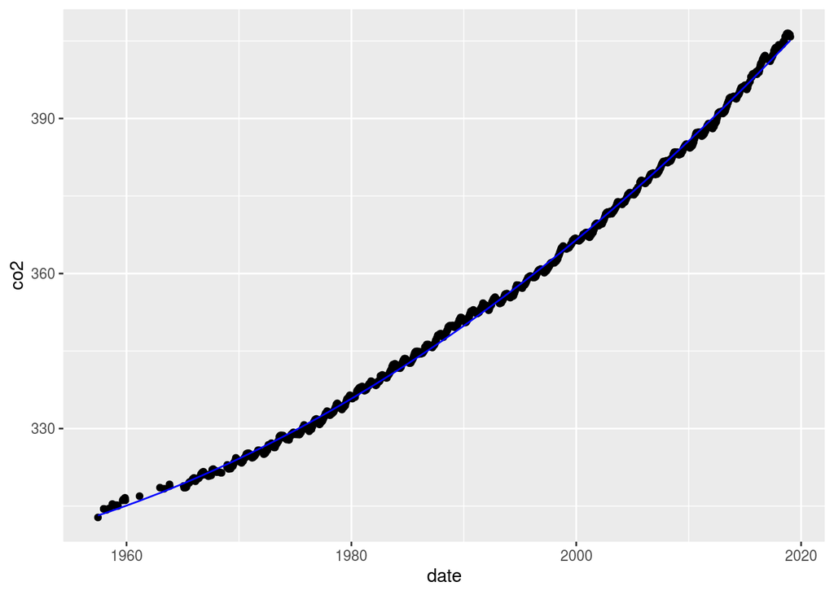

```r
co2_model2 <- augment(co2_fit2, co2_sq)

ggplot(co2_model2,
       aes(x = date, y = co2)) +
  geom_point() +
  geom_line(aes(y = .fitted), colour="blue")
```

### Q14. Plot the residuals

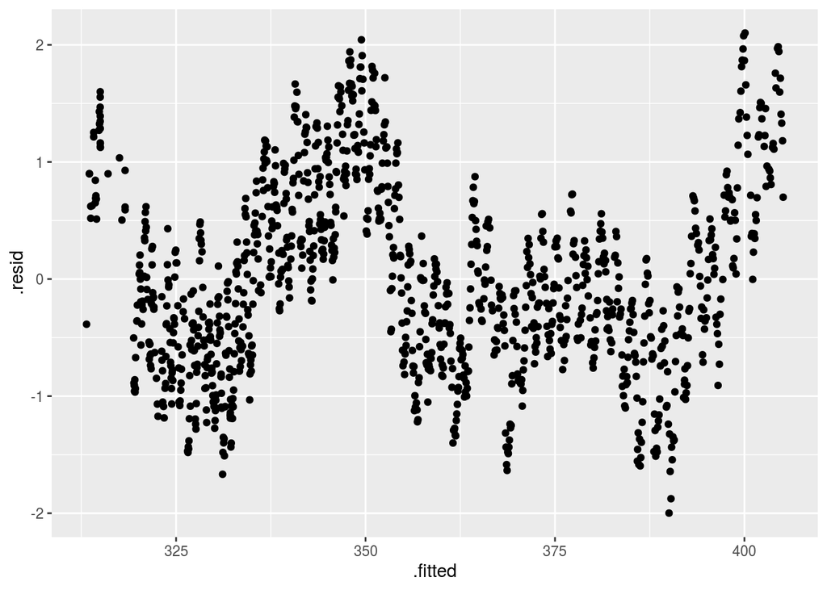

```r
ggplot(co2_model2,
       aes(x = .fitted, y = .resid)) +
  geom_point()
```